This document is providing the different steps used to analyse sequenced amplicons of potentially entomopathogenic microsporida and protists. The amplicons were amplified with different set of primers found in the pr2‐primers database (Vaulot et al., ‘Pr2‐primer’) and sequenced with a MinION sequencer, a R.9 flowcell and the kits EXP-NBD104/SQK-LSK109.

# Check if guppy_basecaller is already installed in your machine

Install guppy on a Linux machine (https://community.nanoporetech.com/docs/prepare/library_prep_protocols/Guppy-protocol/v/gpb_2003_v1_revan_14dec2018/linux-guppy). Depending on whether we are running the basecalling on CPU GPU, we will need to choose an appropriate Guppy package.

Add Oxford Nanopore’s deb repository to your system (this is to install Oxford Nanopore Technologies-specific dependency packages):

```
sudo apt update
sudo apt install wget lsb-release
export PLATFORM=$(lsb_release -cs)
wget -O- https://cdn.oxfordnanoportal.com/apt/ont-repo.pub | sudo apt-key add -
echo "deb http://cdn.oxfordnanoportal.com/apt ${PLATFORM}-stable non-free" | sudo tee /etc/apt/sources.list.d/nanoporetech.sources.list
sudo apt update
```

To install the .deb for Guppy, use the following command:

```
sudo apt update
sudo apt install ont-guppy
```

This will install the GPU version of Guppy.

or:

```
sudo apt update
sudo apt install ont-guppy-cpu
```

To install the CPU-only version of Guppy. The GPU option works with NVIDIA build (https://github.com/asadprodhan/GPU-accelerated-guppy-basecalling/blob/main/README.md) and will need appropriate CUDA drivers to be installed on your system. It is faster to run the basecalling with the GPU, if possible.

We can find your graphic card with:

```
sudo lshw -C display
```

# Basecalling and barcoding of fasta5 files

## Basecalling with guppy_basecaller

To call out a list of available flow cells plus kit combinations, and their associated config files, use the command:

```
guppy_basecaller --print_workflows
```

Here we are using the –flowcell FLO-MIN106 and –kit SQK-LSK109.

If we look for a specific configuration to use, use the commend:

```
guppy_basecaller --print_workflows | SQK-LSK109
```

We can see that the corresponding configuration for our flowcell and kit is dna_r9.4.1_450bps_hac.

The working directory for the following analysis is /home/Shared/Minion/Minion060522/EdouardInsects_bw/try4/20220509_1222_MN39555_FAT01120_159cc567/guppy_basecalling_Run060522/. In the following document, the path of files seen a ‘~/folder/file’, ~ refers to the working directory.

To perform the basecalling we use the command:

```
guppy_basecaller --disable_pings -i fast5/ -s /fastq_pass_07122022 -c dna_r9.4.1_450bps_hac.cfg --min_qscore 7 --compress_fastq --cpu_threads_per_caller 14 --num_callers 1
```

The directory contains the following output:

```
drwxr-xr-x  2 root root    4096 Dec  7 06:42 fail
drwxrwxr-x  6 root root    4096 Dec  7 01:21 guppy_basecaller-core-dump-db
-rw-r--r--  1 root root     180 Dec  7 01:21 guppy_basecaller_log-2022-12-07_01-21-19.log
-rw-r--r--  1 root root    1005 Dec  7 01:22 guppy_basecaller_log-2022-12-07_01-22-05.log
-rw-r--r--  1 root root    1007 Dec  7 01:39 guppy_basecaller_log-2022-12-07_01-39-25.log
-rw-r--r--  1 root root    1059 Dec  7 01:41 guppy_basecaller_log-2022-12-07_01-41-19.log
-rw-r--r--  1 root root    1061 Dec  7 02:25 guppy_basecaller_log-2022-12-07_02-25-53.log
-rw-r--r--  1 root root    1105 Dec  7 03:27 guppy_basecaller_log-2022-12-07_03-27-14.log
-rw-r--r--  1 root root    1103 Dec  7 03:41 guppy_basecaller_log-2022-12-07_03-41-25.log
-rw-r--r--  1 root root 5242849 Dec  7 05:52 guppy_basecaller_log-2022-12-07_03-43-48.log
-rw-r--r--  1 root root 1521114 Dec  7 06:42 guppy_basecaller_log-2022-12-07_05-52-17.log
drwxr-xr-x  2 root root    4096 Dec  7 06:42 pass
-rw-r--r--  1 root root 5668525 Dec  7 06:42 sequencing_summary.txt
-rw-r--r--  1 root root  418664 Dec  7 06:42 sequencing_telemetry.js
```

Usually, we should merge all resulting ‘passed’ fastq files into a single file:

```
cat *.gz > /home/edouard/pass_cat.fastq.gz
sudo bash -c 'cat *.fastq > Barcode01_cat.fastq'
```

In order to get the number of reads in our fastq file, we can count the number of lines and divide by 4:

```
zcat pass_cat.fastq.gz | wc -l | awk '{print $1/4}'
```

Here we have **20006** read within the pass folder, and 4851 within the fail folder.

We can have a quick sequencing summary and basic statistics with NanoStat (https://github.com/wdecoster/nanostat), the input file formats are fastq, bam or albacore sequencing summary format. Here we use the ‘sequencing_summary.txt’ from the guppy basecalling.

```
NanoStat --summary :/home/Shared/Minion/Minion060522/EdouardInsects_bw/try4/20220509_1222_MN39555_FAT01120_159cc567/guppy_basecalling_Run060522/sequencing_summary.txt
```

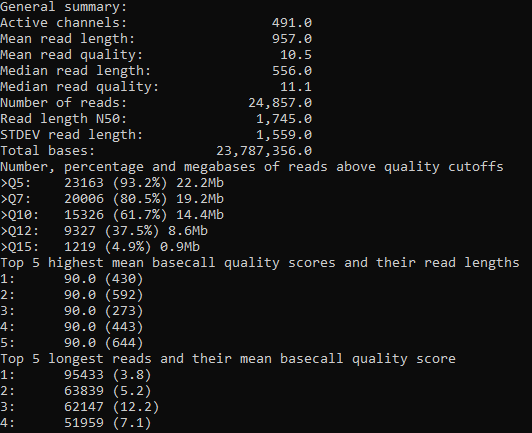

Sequencing (06/05) summary after basecalling

We can also visualise some plots with the command Nanoplot (https://github.com/wdecoster/NanoPlot). NanoPlot creates: a statistical summary, a number of plots and a html summary file. Here we use the ‘sequencing_summary.txt’ file from the guppy_basecalling to generate the report:

```
NanoPlot --summary /home/Shared/Minion/Minion060522/EdouardInsects_bw/try4/20220509_1222_MN39555_FAT01120_159cc567/guppy_basecalling_Run060522/sequencing_summary.txt -o nanoplot_basecalling_Run060522
```

We can see with the plot ‘Read lengths vs. Average read quality’ that the majority of our reads have a length of 200-600 bp, with few reads around 1700-1900 bp and a q score varying between 4 and 16.

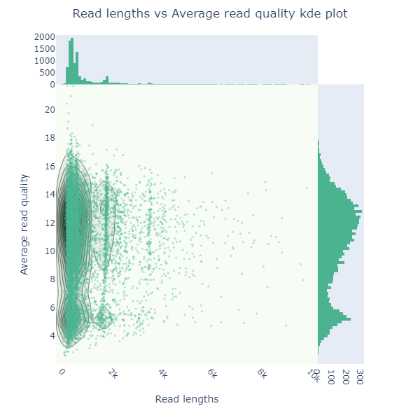

NanoPlot

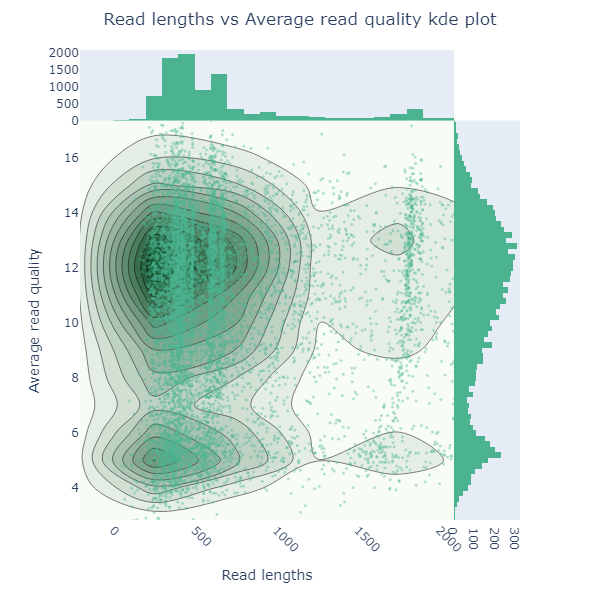

NanoPlotZoom

PS: Nanoplot is not added to the path is it is ran from the home directory with ‘/home/edouard/.local/bin/NanoPlot’.

## Barcoding with guppy_barcoder

After basecalling, we perform the demultiplixing of the previously generated fast.gz files with the command:

[output not shown]

NB: the barcodes are by default trimmed by guppy_barcoder command, so the resulting reads are completely demultiplexed. To keep the barcode sequences we need to add to the command line –disable_trim_barcodes.

The output folder of the barcoding looks like this:

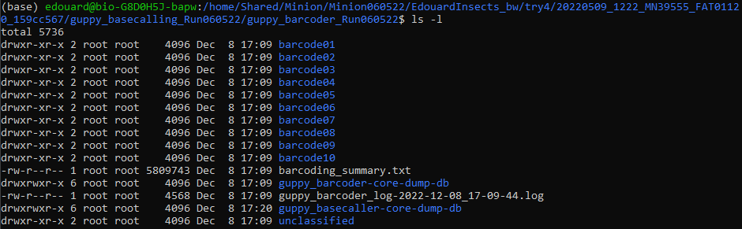

Output folder of guppy_barocder

The obtained fastq files look like this (e.g. from barcode 01):

```
@9583c94e-5237-443b-be2e-da7904ea5e72
runid=cd2409afdc364972d4e64953023ac179690563d1
sampleid=try4
read=14947
ch=365
start_time=2022-05-09T18:37:03Z
model_version_id=2021-05-17_dna_r9.4.1_minion_384_d37a2ab9
barcode=barcode01
TGAATTGACGAGA...
```

To extract key information from the barcoding_summary.txt file, we can use standard text processing tools. Here are some examples of commands to use.

1. Number of reads per barcode:

   awk ‘NR>1 {print $2}’ barcoding_summary.txt | sort | uniq -c

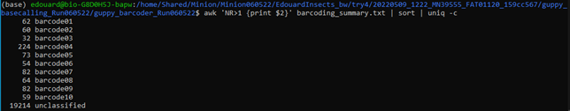

We can see that 19 214 reads are unclassified, and thus some information is lost. We could then replace the option ‘guppy_barcoder –require_barcodes_both_ends’ with ‘–detect_mid_strand_barcodes’, as during the ligation protocol, barcodes end up ligating in the middle of the samples:

[output not shown]

After running the command we have a better classification of our reads among the barcodes, but with potentially a higher error during the demultiplexing of our reads.

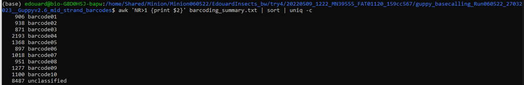

2. Barcode quality:

The following cmd will extract the sixth column (barcode score) for each line in the barcoding_summary.txt file, which can be used as a measure of read quality.

```
awk '{print $2,$6}' barcoding_summary.txt | awk '{sum[$1]+=$2; count[$1]++} END {for (barcode in sum) print barcode, sum[barcode]/count[barcode]}'
```

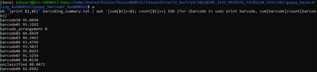

Barcode quality with barcodes at both end required.

We can see that the quality of each barcode is decreasing when we use the cmd ‘-- detect_mid_strand_barcodes’

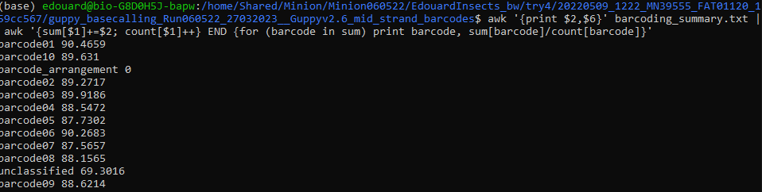

Barcode quality with mid_strand_barcodes required.

3. Displaying the number of bases per barcode

This can be useful for checking depth. Remember that some kits use PCR based reads (therefore they are all likely to be similar lengths) and others use native (e.g. straight from extraction) nucleic acid (which might range a lot in size, from a few hundred to hundreds of thousands of bp). To display number of bases for total sequencing run:

```
awk '{sums[$23] += $14} END { for (i in sums) printf("%s %s\n", i, sums[i])}' barcoding_summary.txt | sort
```

$23 = column 23 which is alias (e.g. barcode number) $14 = column 14 which is sequence_length_template (e.g. number of bases). This is the column we need to multiply to get total number of bases per barcode.

Eventually, we can also put the demultiplexed reads into a table for analysis (Tyson et al., 2020):

```
fastq pass/barcode{}/*.fastq >> reads.csv
```

We can convert the demultiplexed fastq files into fasta files to perform blast search.

```
seqtk seq -a  barcode01/fastq_runid_34c4b5f07d5fc45d2ef4eec699d4c96aff6a02c7_0.fastq > barcode01/barcode01_Run060522.fasta
```

A megablast search is eventually performed with each sample/barcode fasta file on NCBI.

The blast search allows us to align our reads to the nr database available on NCBI. But here we are limited our search to the expected amplified microsporidia and protists, while also including non-targeted groups. The following parameters for the blast search are used. The example with the sample *Aphomia sociella* shows that we include our expected amplified organisms (gregarines, kinetoplastids, amoebozoa) while including non-targeted sequences to check the specificity of the used primers.

[figure not shown]

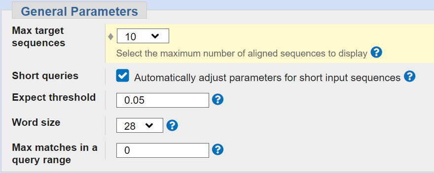

The hit table is screened for alignment that has a % identity superior at 95% and a alignment length of minimum 150bp.

Then the accession number are used to have the corresponding organism with the command:

```
epost -db nuccore -input barcode4.txt | esummary
| xtract -pattern DocumentSummary -element AccessionVersion,Organism
```

Rather than using the blast search with our individual reads, we can perform an OTU classification. This relies on databases cataloging reference OTUs identified through clustering (such as PR2, a database specific for 18S protists sequences). This can be achieved with the tool Qiime2.

# Qiime2 (Bolyen et al., 2019)

To install Qiime2, we can follow the instructions from here https://docs.qiime2.org/2022.8/install/.

Initiate qiime2 environment to start the analysis:

```
conda activate qiime2-2023.5
qiime --help
```

To deactivate the quiime environment:

```
conda deactivate
```

## Import of data in Qiime2

Qiime is using ‘artifacts’. Artifacts represent intermediate data in a qiime analysis, that are “intended to be consumed by QIIME 2”. Intermediate artifacts have the extension .qza, which stands for QIIME Zipped Artifact. Whereas, a terminal output ready for “human consumption” will typically have the extension .qzv, which means QIIME Zipped Visualization (https://gregcaporaso.github.io/q2book/back-matter/glossary.html?highlight=qza).

The first step for our qiime analysis is to import our data with:

```
qiime tools import
```

To import our data (i.e., demultiplexed single end fatsq files) we need to create a manifest file. A ‘manifest file’ is needed to import fastq files that do not follow specific formats (i.e. EMP or Casava formats). Since we are importing demultiplexed fastq files (without barcode sequences), we need to import our own “Fastq manifest” (https://docs.qiime2.org/2022.8/tutorials/importing/). Example of manifest format:

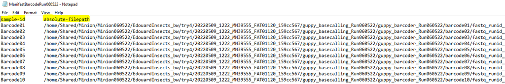

ManifestFile

Our manifest file only have two columns, the sample-id (i.e. barcode) and the path for the demultiplexed fastq files (single reads).

It seems more appropriate to perform the qiime analysis with the barcode/sample treated independently (Kenmotsu et al., 2021). Then our data are independently imported into QIIME2. In this way, we can use specific classifier for each barcode (see further).

In the folder ‘~/guppy_barcoder_Run060522/barcode01’ we have the demultiplexed fastq file that we will import in qiime, thanks to a manifest, with the command line:

```
qiime tools import --type 'SampleData[SequencesWithQuality]' --input-path ManifestBarcode01_Run060522.txt --output-path AsNB01_Run060522.qza --input-format SingleEndFastqManifestPhred33V2
```

The same import procedure is applied to the rest of the barcodes.

We can look at the visualisation of all the barcodes (qiime artifacts saved in ‘~/Qiime2_Run060522_121222/’)’, we can see that the numbers of reads per barcode vary from 32 (barcode 03, *Galleria mellonella*) to 224 (barcode 04, *Schistocerca gregaria*, only SSU amplicons).

We can also import all the barcodes at once.

```
qiime tools import --type 'SampleData[SequencesWithQuality]' --input-path ManifestBarcodeRun060522.txt --output-path Qiime2_QZA_Barcodes_Run060522.qza --input-format SingleEndFastqManifestPhred33V2
```

To visualise the data we used the command line:

```
qiime demux summarize --i-data Qiime2_QZA_Barcodes_Run060522.qza --o-visualization Qiime2_Barcodes_Run060522_visu.qzv
```

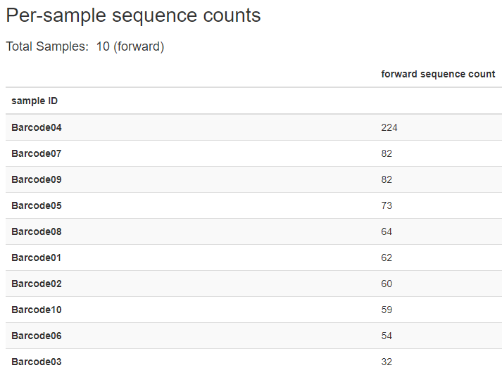

Qiime2_Barcodes_Run060522_visu.qzv

And the Qiime2_Barcodes_Run060522_visu.qzv file has been uploaded on the website https://view.qiime2.org/. We can also observe the Interactive Quality Plot.

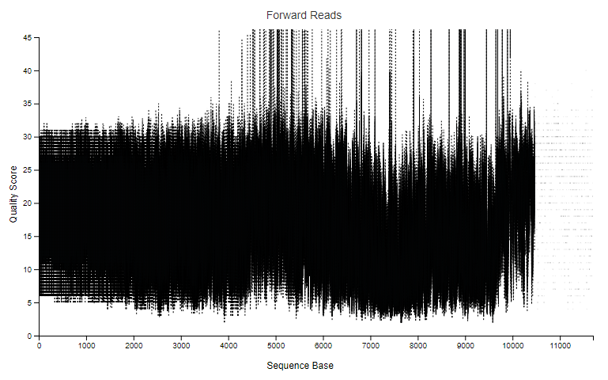

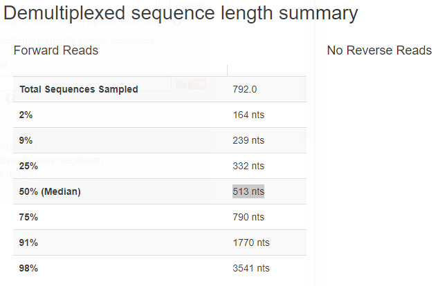

## Denoising with dada2

```
qiime dada2 denoise-single \
--p-n-threads 12 \
--i-demultiplexed-seqs Qiime2_QZA_Barcodes_Run060522.qza \
--p-trunc-len 0 \
--p-trim-left 100 \
--output-dir DADA2_denoising_Barcodes_Run060522 \
--verbose \
```

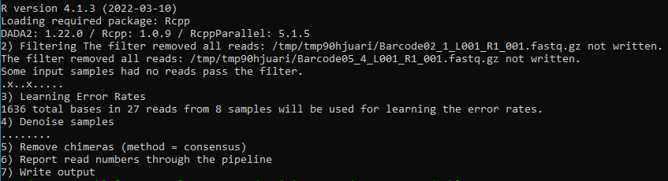

Command dada2

Good to know that we have the following default parameters

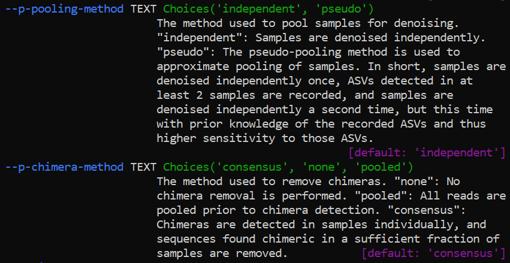

qiime dada2 denoise-single ‘pooling’ and ‘chimera’ default parameters

The output of *qiime dada2 denoise-single* on the demultiplexed data is composed by a feature table *FeatureTable[Frequency]*, the resulting feature sequences *FeatureData[Sequence]*, and the denoising stats *SampleData[DADA2Stats]*.

### Generate summary files¶

Feature table

```
qiime feature-table summarize \
--i-table table.qza \
--o-visualization table.qzv \
```

How many sequences have been filtered?

```
qiime metadata tabulate \
--m-input-file denoising_stats.qza \
--o-visualization denoising_stats_Barcodes_Run060522.qzv \
--verbose
```

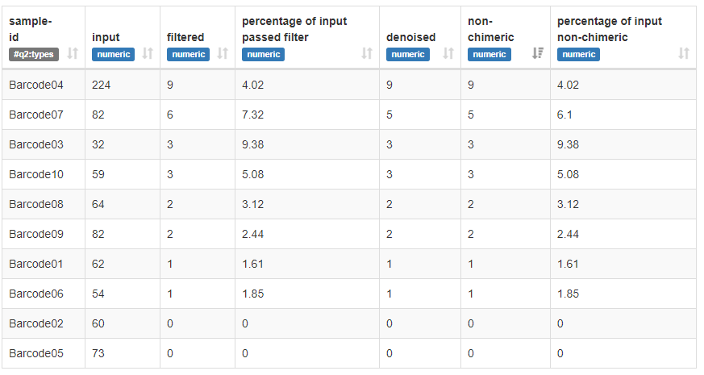

Visualisation of denoising_stats_Barcodes_Run060522.qzv

Do BLAST searches of the representative sequences make sense? blast the sequences in *FeatureData[Sequence]*. To have the Sequence Length Statistics with our different sequences, we use the following command:

```
qiime feature-table tabulate-seqs \
--i-data representative_sequences.qza \
--o-visualization representative_seqs_Barcodes_Run060522.qzv \
--verbose
```

Only 8 sequences (from 792) in *representative_seqs_Barcodes_Run060522.qzv*. We have a large number (>50%) of sequences that has been lost during denoising/filtering. The settings are too stringent. The new parameters are used:

```
qiime dada2 denoise-single \
--p-n-threads 12 \
--i-demultiplexed-seqs Qiime2_QZA_Barcodes_Run060522.qza \
--p-trunc-len 0 \
--p-max-ee 10 \
--p-trunc-q 0 \
--p-chimera-method 'none' \
--output-dir DADA2_denoising_Barcodes_Run0605224 \
--verbose \
```

The filtering is softened when **max-ee** is increased (https://github.com/benjjneb/dada2/issues/248). Some reads correspond to gregarines, but still too few reads are available.

Then, we will skip the denoising step as we are losing too much reads (we aslo have very few reads from the sequencing run). We will classify our demultiplexed reads with the PR2 database (an 18S database for protists).

## Use the PR2 Database in Qiime2 for classifying

### Import the PR2 Database and train the classifier

The following commands can be used to import the PR2 reference database and its corresponding taxonomy as qimme artifacts https://pr2-database.org/documentation/pr2-files/:

```
qiime tools import --type 'FeatureData[Sequence]' --input-path pr2_version_4.14.0_SSU_mothur.fasta --output-path PR2_otus.qza

qiime tools import --type 'FeatureData[Taxonomy]' --input-format HeaderlessTSVTaxonomyFormat --input-path pr2_version_4.14.0_SSU_mothur.tax --output-path PR2-taxonomy.qza
```

After importing our reference database, we need to train our ‘classifier’ against reference sequences (e.g. with the PR2 data):

```
qiime feature-classifier fit-classifier-naive-bayes --i-reference-reads PR2_otus.qza --i-reference-taxonomy PR2-taxonomy.qza --o-classifier PR2classifier.qza
```

The resulting classifier will serve to classify our own reads.

```
qiime feature-classifier classify-sklearn --i-classifier /home/Shared/PR2database/PR2classifier.qza --i-reads Qiime2_QZA_Barcodes_Run060522.qza --o-classification PR2-taxonomy-Barcodes_Run060522.qza
```

We have the following error *Invalid value for ‘–i-reads’: Expected an artifact of at least type FeatureData[Sequence]. An artifact of type SampleData[SequencesWithQuality] was provided*. To resolve this we need to convert our artifact Qiime2_QZA_Barcodes_Run060522.qza from SampleData[SequencesWithQuality] to FeatureData[Sequence].

### Dereplicate the sequences

We dereplicate our SampleData artifact with vsearch cmd. It will dereplicate our [SampleData] and indicate the number of times each amplicon sequence variant (ASV) is observed in each of our samples. No quality filtering is done with this tool, so we do not loose information (compared to dada2).

```
qiime vsearch dereplicate-sequences --i-sequences Qiime2_QZA_Barcodes_Run060522.qza --o-dereplicated-table dereplicatedtable_Qiime2_QZA_Barcodes_Run060522.qza --o-dereplicated-sequences Qiime2_QZA_Barcodes_Run060522_dereplicated.qza
```

### Classification with trained classifier

We reperform the classification with the dereplicated sequence.

```
qiime feature-classifier classify-sklearn --i-classifier /home/Shared/PR2database/PR2classifier.qza --i-reads Qiime2_QZA_Barcodes_Run060522_dereplicated.qza --o-classification PR2-taxonomy-Barcodes_Run060522.qza
```

### Visualize our taxonomies by entering the following

We can now visualise the obtained OTU classification with:

```
qiime metadata tabulate --m-input-file PR2-taxonomy-Barcodes_Run060522.qza --m-input-file Qiime2_QZA_Barcodes_Run060522_dereplicated.qza --o-visualization taxonomy-Barcodes_Run060522.qzv
```

### Taxonomic bar plots were generally created as follows:

```
qiime taxa filter-table \
    --i-table dereplicatedtable_Qiime2_QZA_Barcodes_Run060522.qza \
    --i-taxonomy PR2-taxonomy-Barcodes_Run060522.qza \
    --p-mode exact \
    --p-exclude "Eukaryota" \
    --o-filtered-table Barcodes_Run060522_filtered.qza
```

Command for barplots:

```
qiime taxa barplot \
--i-table Barcodes_Run060522_filtered.qza \
--i-taxonomy PR2-taxonomy-Barcodes_Run060522.qza \
--o-visualization Barcodes_Run060522_barplots_filtered.qzv
```

We can check the remaining read counts after filtering:

```
qiime feature-table summarize \
--i-table Barcodes_Run060522_filtered.qza \
--o-visualization Barcodes_Run060522_filtered.qzv
```

## Other taxonomy classification option (amplicon specific classifier)

Then, to classify our reads, we will need a reference database. We can use the plugin qiime rescript (https://github.com/bokulich-lab/RESCRIPt) to easily import the SILVA database (Robeson et al., 2021):

```
qiime rescript get-silva-data --p-version '138.1' --p-target 'LSURef_NR99' --p-include-species-labels --o-silva-sequences silva-138.1-lsu-nr99-seqs.qza --o-silva-taxonomy silva-138.1-lsu-nr99-tax.qza
```

We have to convert the rRNA sequences into rDNA:

```
qiime rescript reverse-transcribe --i-rna-sequences silva-138.1-ssu-nr99-seqs.qza --o-dna-sequences silva-138.1-ssurDNA-nr99-seqs.qza
```

As we are analysing our samples individually, we will use amplicon-specific classifiers. For each sample, we will generate amplicon-specific classifiers (https://forum.qiime2.org/t/processing-filtering-and-evaluating-the-silva-database-and-other-reference-sequence-data-with-rescript/15494#heading--sixth-header). Constructing such classifiers allow for more robust taxonomic classification of our data (Werner et al. 2011, Bokulich et al. 2018).

### Barcode 01

The barcode 01 represents the sample *Aphomia sociella* which had expected amplicons obtained with the group specific primers: - Gregarines (SSU): forward-CCCTTAGATRRYCTGGGCTGC and reverse-CGTGTTACGACTTCTTC - Kinetoplastea (SSU): forward-CTGCCAGTAGTCATATGCTTGTTTCAAGGA and reverse-GATCCTTCTGCAGGTTCACCTACAGCT - Amoebozoa (SSU): forward-GAATTGACGGAAGGGCACAC and reverse-CCAAGAYRTCTAAGGGCATCAC (see excel file ‘PCRprod_NanoporeExp_05-05-2022_02-06-2022’).

It is recommended to trim the primers from the data with dada2 prior classification, however this can be discussed: https://www.researchgate.net/post/Is_it_mandatory_to_remove_primers_and_barcodes_from_reads_before_starting_the_analyzes_in_qiime_2.

The primers can be removed with the command (this step is omitted here):

```
qiime cutadapt trim-paired \
--i-demultiplexed-sequences file.qza \
--p-front-f forward_primer_sequence \
--p-front-r reverse_primer_sequence \
--p-error-rate 0.20 \
--output-dir analysis/seqs_trimmed \
--verbose
```

The error rate parameter, –p-error-rate, will likely need to be adjusted to get 100% (or close to it) of reads trimmed.

#### Classifier for Gregarines (SSU)

To generate our amplicon-specific classifier, we use the silva database silva-138.1-SSUrDNA-nr99-seqs.qza (/home/edouard/Qiime2Databases_Feature-classifier):

```
qiime feature-classifier extract-reads \
    --i-sequences /home/edouard/Qiime2Databases_Feature-classifier/silva-138.1-SSUrDNA-nr99-seqs.qza \
    --p-f-primer CCCTTAGATRRYCTGGGCTGC \
    --p-r-primer CGTGTTACGACTTCTTC \
    --p-min-length 50 \
    --p-max-length 1000 \
    --p-n-jobs 2 \
    --p-read-orientation 'forward' \
    --o-reads silva-ssu-gregFgregR.qza
```

Now we can build our amplicon-region specific classifier.

```
qiime feature-classifier fit-classifier-naive-bayes \
    --i-reference-reads silva-ssu-gregFgregR.qza \
    --i-reference-taxonomy /home/edouard/Qiime2Databases_Feature-classifier/silva-138.1-ssu-nr99-tax.qza \
    --o-classifier silva-ssu-gregFgregR-classifier.qza
```

The output *silva-ssu-gregFgregR-classifier.qza* is a Taxonomic Classifier that we will use for our gregarine amplicons classification. Classify rep seqs with:

```
qiime feature-classifier classify-sklearn\
--i-classifier silva-ssu-gregFgregR-classifier.qza\
--i-reads AsNB01_Run060522.qza\
--o-classification classified_AsNB01_Run060522.qza
```

We have the error *Invalid value for ‘–i-reads’: Expected an artifact of at least type FeatureData[Sequence]. An artifact of type SampleData[SequencesWithQuality] was provided*. We dereplicate our SampleData artifact Qiime2_Allbarcodes.qza with vsearch cmd. It will dereplicate our SampleData and indicate the number of times each amplicon sequence variant (ASV) is observed in each of our samples. No quality filtering is done with this tool, so we do not loose information.

```
qiime vsearch dereplicate-sequences --i-sequences AsNB01_Run060522.qza --o-dereplicated-table dereplicatedtable_AsNB01_Run060522.qza --o-dereplicated-sequences AsNB01_Run060522_dereplicated.qza
```

We reperform the classification with the dereplacted sequence.

```
qiime feature-classifier classify-sklearn\
--i-classifier silva-ssu-gregFgregR-classifier.qza\
--i-reads AsNB01_Run060522_dereplicated.qza\
--o-classification classified_AsNB01_Run060522.qza
```

Finally, we visualise our taxonomies and the confidence of taxonomy assignment by entering the following command:

```
qiime metadata tabulate\
--m-input-file classified_AsNB01_Run060522.qza\
--o-visualization classified_AsNB01_Run060522_visu.qzv
```

Most of the reads are just classified as eukaryotes.

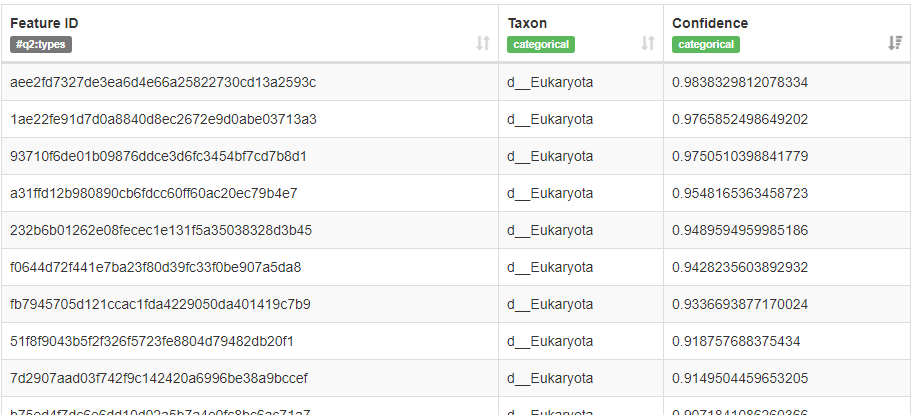

# Analyse the barcoded reads with blast program and perform phylogeny

## Install the latest blast program on our machine

1. We can download the compressed archive file from the NCBI website using wget:

   wget ftp://ftp.ncbi.nlm.nih.gov/blast/executables/blast+/2.13.0/ncbi-blast-2.13.0+-x64-linux.tar.gz
2. Then, we extract the contents of the archive file using tar. tar -xvf ncbi-blast-2.13.0+-x64-linux.tar.gz Inside the extracted folder ‘ncbi-blast-2.13.0+’, we find a bin directory. This is where the BLAST executable live.
3. To set up BLAST, we need to add these executable to our environment’s PATH variable. The easiest way to do this is to enter the bin directory and then run:

   export PATH=$PATH:$PWD

After running this command we should be able to execute any of the BLAST programs from the current shell. To make this available permanently, we need to add the following line to your ‘HOME/.bash_profile’ file.

```
export PATH="/home/edouard/ncbi-blast-2.13.0+/bin:$PATH"
```

If you don’t have a ‘HOME/.bash_profile’ file, just create one. Recall that $HOME refers to the location of your home directory.

5. Type ‘source .bash_profile’ to reload .bash_profile and update any functions you add.
6. Verify that the installation was successful by running the blastp command with the –version option.

   blastn -version

## Download the reference reads that will be used for alignment

To download LSU sequences for Microsporidia from the nr database with use the following line:

```
esearch -db nucleotide -query ""Microsporidia"[Organism] AND (28S[All Fields] OR LSU[All Fields])" | efetch -format fasta > output.fasta
```

With: - ‘esearch’: This command is used to search the NCBI database. - ‘-db nucleotide’: This option specifies the database to be searched, which in this case is the nucleotide database. - ‘efetch’: This command is used to retrieve the search results.

We can dereplicate the sequences with:

```
cd-hit-est -i output.fasta -o LSU_Microsporidia_derep_inf5000.fasta -c 0.95 -n 5
```

Note that the clustering results will be stored in a separate file with the suffix “.clstr” appended to the output file name (i.e. output_derep.fasta.clstr). This file contains information about the clusters formed by the clustering algorithm, including the number of sequences in each cluster and the identity of the representative sequence for each cluster.

This will remove any sequences longer than 5000 bases:

```
seqkit seq -M 5000 LSU_Microsporidia_derep_inf5000.fasta > output_filtered.fasta
```

## Make a database for blast

Download fasta file from NCBI search Alveolata[ORGN] OR Ciliophora[ORGN] OR Amoebozoa[ORGN] OR Helicosporidium[ORGN] OR Euglenozoa[ORGN] OR Ichthyosporea[ORGN] OR Microsporidia[ORGN] AND 28S[ALL] AND 18S[ALL] (Nucleotide 7,393) ##joint with PR2 database

```
makeblastdb -in MajorProtists18Sand28S_NCBI_Nucleotide.fa -title MajorProtists18Sand28S_DB -dbtype nucl -out MajorProtists18Sand28S_DB -parse_seqids
```

# Useful bash cmd

Find the location of a folder:

```
locate folder | grep folder$
locate -b filename
locate -b '\\dir1'
```

We can count how many times appear a specific sub sequence into fastq files:

```
> zgrep -c 'ATGATGATG' reads.fq.gz
    398065
> zcat reads.fq.gz | awk '/ATGATGATG/ {nlines = nlines + 1} END {print nlines}'
    398065
```

Linux check disk space with df command:

```
df
df -H
```

See running process/jobs:

```
htop
```

Stop or terminate Linux command process with **CTRL + C or CTRL + Z**

See jobs running with:

```
jobs -l
```

Stop a specific job ID using the **kill** command. Here is an example:

```
kill <job ID>
```

Restarts a background process. If you don’t provide a job number the last process that was turned into a background task is used.

```
bg <job ID>
```

You can also use the **pkill** command to stop a process by name. Here is an example:

```
pkill <process name>
kill -9 <PID> #force kill
```

Use the following command to print the files inside each folder:

```
for d in barcode*; do echo "$d:"; ls "$d"; done
```

Extract compressed file with

```
tar -xzf file.tar.gz
tar -xvzf file.tgz
tar -xf file.zip
```

If you want to extract the contents of the .tgz file into a specific directory, you can use the following command:

```
tar -xvzf file.tgz -C /path/to/directory
```

Remove chimeric reads in fastq files To count the number of chimeric reads in your FASTQ files, you can use a tool such as Porechop or another adapter trimming tool that is capable of detecting and removing chimeric reads. For example, to use Porechop to identify and trim chimeric reads in your FASTQ files:

```
porechop -i input.fastq -o output.fastq --discard_middle
```

This command runs Porechop with the -i option to specify the input FASTQ file, the -o option to specify the output FASTQ file, and the –discard_middle option to discard any reads that contain a chimeric adapter sequence in the middle. The output FASTQ file will contain only the reads that passed the chimeric read filter.

Blastn with the pass basecalled fastq files

```
nohup blastn -query pass_cat.fasta -db nr -outfmt '6 qseqid sseqid stitle pident length mismatch gapopen qstart qend sstart send evalue bitscore ssciname' -out blastn_passbasecall_0506.txt -max_target_seqs 10 -perc_identity 90 -qcov_hsp_perc 90 -remote
```

rm Use the command gzip -d filename.gz to extract a .gz file

To combine two FASTA files into one file in Linux, you can use the following command:

```
cat file1.fasta file2.fasta > combined.fasta
```

This command concatenates the contents of file1.fasta and file2.fasta and writes the output to a new file called combined.fasta.

Alternatively, you can use the following command:

```
cat *.fasta > combined.fasta
```

To move multiple files into one directory in Linux, you can use the mv command. The syntax is as follows:

```
mv file1 file2 file3 /path/to/destination
```

To count the total number of hits from blastn output, you can use the following command on the tabular output format:

```
cut -f1 <blast result file> | sort -u | wc -l
```

This will print a number which represents the number of your query sequences that match your database

Use the following command to count the number of raw sequences by number of lines divided by 4 in a fastq file:

```
echo $((($(wc -l < input.fastq) / 4)))
```

Use the following bash command to count the number of sequences in your fasta file:

```
grep ">" file.fasta | wc -l
```

This command will count the number of lines that start with the “>” character in your fasta file, which corresponds to the number of sequences in your file.

This command shows the available and used disk space for each filesystem. You can use the -h option to display the output in human-readable format, such as MB or GB.

```
df -h.
```

To add a command permanently to your environment, modify the .bash_profile file and add (as an example):

```
sudo nano .bash_profile
export PATH="$PATH:/home/tomahawk/tools/jdk1.8.0_92/bin"
```

To get statistics on your FASTQ files, such as min, max, and mean sequence length, run the following command:

```
seqkit stats your_file.fastq
```

To download a file from the web:

```
wget https://raw.githubusercontent.com/avierstr/amplicon_sorter/master/amplicon_sorter.py
```

See used docker container

```
sudo docker ps -a
```

Remove docker containers

```
sudo docker container prune
```

See sizes of folders in descending order

```
du -sh * | sort -hr
```

To return the number of files in a current directory use:

```
ls -1 | wc -l
```

See all threads on linux machine

```
ps -eLf
ps -ef
```

Check graphic card status

```
nvidia-smi
```

Information about system:

```
neofetch
```

Remove contigs based on contig name with:

```
awk 'NR==FNR { contaminants[">" $0]; next } /^>/ { print_seq(); header=$0; seq=""; next } { seq = seq $0 } END { print_seq() } function print_seq() { if (header && !(header in contaminants)) print header "\n" seq }' contaminants_id.txt assembly.fasta.masked > filtered_assembly.fasta
```

Make meryl db First estimate the kmer size with the formula: LOG((genome size in bp*(1-0.001)/0.001),4) where 0.001 is the tolerable collision rate

```
meryl count k=16 input.fasta output folder_name && tar -zcf folder_name.meryldb folder_name
```

Filter specific contigs (from a txt file) out of a fasta file:

```
seqkit grep -v -n -f blasted_contigs.txt HyPo_Gb_microsporidia_polished_assembly.fasta > remaining_contigs.fasta
```